# LBB Classification 1

Francis Yeh

28 Mar 2020

# 1 Introduction

## 1.1 Background

Imagine you are employed at a particular conglomerate distributing FMCG goods through a distribution network consisting of hotel, restaurant, cafes and all variety of retail outlets. Our CRM system collected the annual spending in each of the product category for each of the customers, and we like to build an algorithm that automatically sort our customers into one of the two segments:

- Horeca: short for Hotel, Restaurant and Cafe Industry sector
- Retail: Retail Industry sector

## 1.2 Data Source

The dataset consists of 440 observations and 8 variables. https://archive.ics.uci.edu/ml/datasets/Wholesale+customers

### 1.2.1 Overview of Variables

1. CHANNEL: customer classification
   - Horeca (Hotel/Restaurant/Cafe) or
   - Retail
2. REGION: customers Region (1 = Lisnon, 2 = Oporto or 3 = Others)
3. FRESH: annual spending (m.u) on fresh products (Continuous);
4. MILK: annual spending (m.u) on milk products (Continuous);
5. GROCERY: annual spending (m.u)on grocery products (Continuous);
6. FROZEN: annual spending (m.u)on frozen products (Continuous)
7. DETERGENTS_PAPER: annual spending (m.u) on detergents and paper products (Continuous)
8. DELICATESSEN: annual spending (m.u)on and delicatessen products (Continuous);

## 1.3 Libraries and Setup

To run the data preparation and the statistical analysis, the following libraries are loaded

Functions used to perform min-max normalization, z-score standardization and accuracy computation of the model

```r
normalize <- function(x){
  return (
    (x - min(x))/(max(x) - min(x))
           )
}

zscore <- function(x){
  return(
    (x-mean(x))/sd(x)
  )
}

accuracy <- function(data){
  correct <- 0
  for (i in c(1:nrow(data))){
    #Compare actual and predicted class
    if(data[i,1] == data[i,2]){
      correct <- correct + 1
    }
  }
  percentage <- correct/nrow(data)*100
  return(percentage)
}
```

# 2 Preprocessing

## 2.1 Data Table

```r
# Read the dataset, remove the "Region" feature
wholesale <- read.csv("data_input/wholesale.csv", header=TRUE)

wholesale <- wholesale[,-2]   # remove Region feature

str(wholesale)
```

```
## 'data.frame':    440 obs. of  7 variables:
##  $ Channel         : int  2 2 2 1 2 2 2 2 1 2 ...
##  $ Fresh           : int  12669 7057 6353 13265 22615 9413 12126 7579 5963 6006 ...
##  $ Milk            : int  9656 9810 8808 1196 5410 8259 3199 4956 3648 11093 ...
##  $ Grocery         : int  7561 9568 7684 4221 7198 5126 6975 9426 6192 18881 ...
##  $ Frozen          : int  214 1762 2405 6404 3915 666 480 1669 425 1159 ...
##  $ Detergents_Paper: int  2674 3293 3516 507 1777 1795 3140 3321 1716 7425 ...
##  $ Delicassen      : int  1338 1776 7844 1788 5185 1451 545 2566 750 2098 ...
```

## 2.2 Checking missing values

```r
any(is.na(wholesale))
```

```
## [1] FALSE
```

Converting Channel to Industry and Make it a Factor

```r
wholesale$Industry <- factor(wholesale$Channel, levels = c(1, 2), labels = c("horeca", "retail"))
wholesale <- wholesale[, -1]  # removing the Channel feature
#table(wholesale$Industry)
round(prop.table(table(wholesale$Industry)) * 100, 2)
```

```
##
## horeca retail
##  67.73  32.27
```

The table shows percentages of horeca (67.73%) and retail(32.27%) customers in the dataset

## 2.3 Normalize the data based on Min-Max Normalization

After trying min-max normalization and z-score standardization separately, we have decided to use min-max normalization as the Nearest Neighbor algorithm yields a higher accuracy.

```r
wholesale.n <- as.data.frame(lapply(wholesale[1:6], normalize))# based on min-max
summary(wholesale.n)
```

```
##      Fresh              Milk            Grocery            Frozen
##  Min.   :0.00000   Min.   :0.00000   Min.   :0.00000   Min.   :0.00000
##  1st Qu.:0.02786   1st Qu.:0.02012   1st Qu.:0.02317   1st Qu.:0.01179
##  Median :0.07580   Median :0.04864   Median :0.05122   Median :0.02467
##  Mean   :0.10698   Mean   :0.07817   Mean   :0.08567   Mean   :0.05008
##  3rd Qu.:0.15097   3rd Qu.:0.09715   3rd Qu.:0.11482   3rd Qu.:0.05800
##  Max.   :1.00000   Max.   :1.00000   Max.   :1.00000   Max.   :1.00000
##  Detergents_Paper     Delicassen
##  Min.   :0.000000   Min.   :0.000000
##  1st Qu.:0.006216   1st Qu.:0.008453
##  Median :0.019927   Median :0.020077
##  Mean   :0.070510   Mean   :0.031745
##  3rd Qu.:0.095997   3rd Qu.:0.037907
##  Max.   :1.000000   Max.   :1.000000
```

```r
## wholesale.z <- as.data.frame(scale(wholesale[, -7]))  # based on z-score normalization
## summary(wholesale.z)
```

```r
wholesale.n <- as.data.frame(cbind(wholesale.n, Industry = wholesale$Industry))
# wholesale.n <- as.data.frame(cbind(wholesale.z, Industry = wholesale$Industry))
# summary(wholesale.n)
wholesale.init <- wholesale.n
```

# 3 Exploratory Data Analysis

## 3.1 Relationship Across Predictors

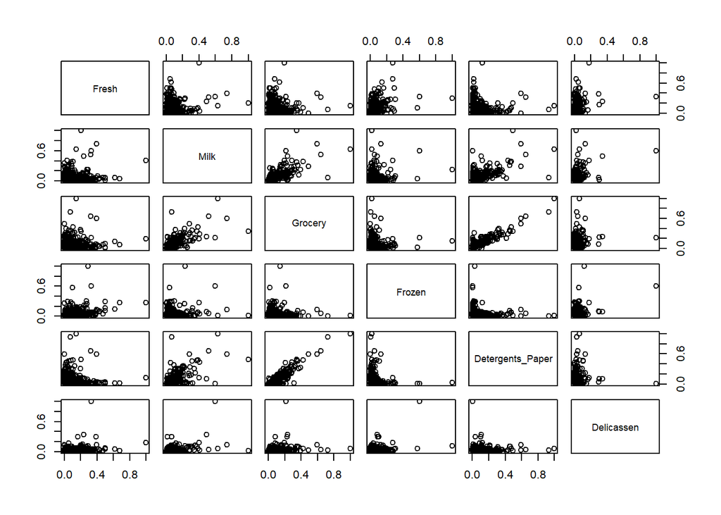

```r
pairs(wholesale.n[1:6])
```

In the plot, we see that grocery and detergents paper are strongly related.

```r
cor(wholesale.n[,1:6])
```

```
##                        Fresh      Milk     Grocery      Frozen Detergents_Paper
## Fresh             1.00000000 0.1005098 -0.01185387  0.34588146       -0.1019529
## Milk              0.10050977 1.0000000  0.72833512  0.12399376        0.6618157
## Grocery          -0.01185387 0.7283351  1.00000000 -0.04019274        0.9246407
## Frozen            0.34588146 0.1239938 -0.04019274  1.00000000       -0.1315249
## Detergents_Paper -0.10195294 0.6618157  0.92464069 -0.13152491        1.0000000
## Delicassen        0.24468997 0.4063683  0.20549651  0.39094747        0.0692913
##                  Delicassen
## Fresh             0.2446900
## Milk              0.4063683
## Grocery           0.2054965
## Frozen            0.3909475
## Detergents_Paper  0.0692913
## Delicassen        1.0000000
```

# 4 Split the data to Train and Test

```r
set.seed(10)
wholesale.n <- wholesale.n[sample(nrow(wholesale.n)), ] # sample
wholesale_train <- wholesale.n[1:352, ]
wholesale_test <- wholesale.n[353:440, ]
#table(wholesale_train$Industry)
round(prop.table(table(wholesale_train$Industry)) * 100, 2)
```

```
##
## horeca retail
##   67.9   32.1
```

```r
wholesale_test_c <- wholesale_test
```

The table shows percentages of horeca (67.9%) and retail(32.1%) customers in the train data.

```r
wholesale_train_labels <- wholesale.n[1:352,7]
wholesale_test_labels <- wholesale.n[353:440,7]
```

# 5 Nearest Neighbor Algorithm

```r
library(class)
wholesale_pred <- knn(train = wholesale_train[ ,-7], test=wholesale_test[ ,-7], cl=wholesale_train_labels, k =25)
```

```r
library(gmodels)
CrossTable(x=wholesale_test_labels,y=wholesale_pred, dnn=c("actual", "prediction"))
```

```
##
##
##    Cell Contents
## |-------------------------|
## |                       N |
## | Chi-square contribution |
## |           N / Row Total |
## |           N / Col Total |
## |         N / Table Total |
## |-------------------------|
##
##
## Total Observations in Table:  88
##
##
##              | prediction
##       actual |    horeca |    retail | Row Total |
## -------------|-----------|-----------|-----------|
##       horeca |        55 |         4 |        59 |
##              |     8.114 |    14.200 |           |
##              |     0.932 |     0.068 |     0.670 |
##              |     0.982 |     0.125 |           |
##              |     0.625 |     0.045 |           |
## -------------|-----------|-----------|-----------|
##       retail |         1 |        28 |        29 |
##              |    16.509 |    28.890 |           |
##              |     0.034 |     0.966 |     0.330 |
##              |     0.018 |     0.875 |           |
##              |     0.011 |     0.318 |           |
## -------------|-----------|-----------|-----------|
## Column Total |        56 |        32 |        88 |
##              |     0.636 |     0.364 |           |
## -------------|-----------|-----------|-----------|
##
##
```

## 5.1 List of observations with differing predicted and actual

[output not shown]

[output cut: 37 more lines]

```r
print(accuracy(wholesale_test_1))
```

```
## [1] 94.31818
```

The accuracy of Nearest Neighbor algorithm is 94.32%

## 5.2 Confusion Matrix

```r
contab0 <- table("predicted"=wholesale_pred,"actual"=wholesale_test_labels)
confusionMatrix(contab0, positive="horeca")
```

```
## Confusion Matrix and Statistics
##
##          actual
## predicted horeca retail
##    horeca     55      1
##    retail      4     28
##
##                Accuracy : 0.9432
##                  95% CI : (0.8724, 0.9813)
##     No Information Rate : 0.6705
##     P-Value [Acc > NIR] : 6.694e-10
##
##                   Kappa : 0.8747
##
##  Mcnemar's Test P-Value : 0.3711
##
##             Sensitivity : 0.9322
##             Specificity : 0.9655
##          Pos Pred Value : 0.9821
##          Neg Pred Value : 0.8750
##              Prevalence : 0.6705
##          Detection Rate : 0.6250
##    Detection Prevalence : 0.6364
##       Balanced Accuracy : 0.9489
##
##        'Positive' Class : horeca
##
```

Preprocessing step for ROC and AUC

```r
wholesale_test_1$wholesale_pred <- as.character(wholesale_test_1$wholesale_pred)
wholesale_test_1$wholesale_test_labels <- as.character(wholesale_test_1$wholesale_test_labels)

wholesale_test_1$wholesale_pred[wholesale_test_1$wholesale_pred == "horeca"] <- 1
wholesale_test_1$wholesale_pred[wholesale_test_1$wholesale_pred == "retail"] <- 0
wholesale_test_1$wholesale_test_labels[wholesale_test_1$wholesale_test_labels =="horeca"] <- 1
wholesale_test_1$wholesale_test_labels[wholesale_test_1$wholesale_test_labels =="retail"] <- 0
wholesale_test_1$wholesale_pred <- as.numeric(wholesale_test_1$wholesale_pred)
wholesale_test_1$wholesale_test_labels <- as.numeric(wholesale_test_1$wholesale_test_labels)
```

## 5.3 ROC Curve

```r
library(ROCR)
# ROCR::prediction(predictions, labels)
wholesaleknn_roc <- ROCR::prediction(wholesale_test_1$wholesale_pred, wholesale_test_1$wholesale_test_labels)
# tpr/ sensitivity: true positive rate
# fpr: false positive rate
roc_knn <- performance(wholesaleknn_roc, "tpr", "fpr")
```

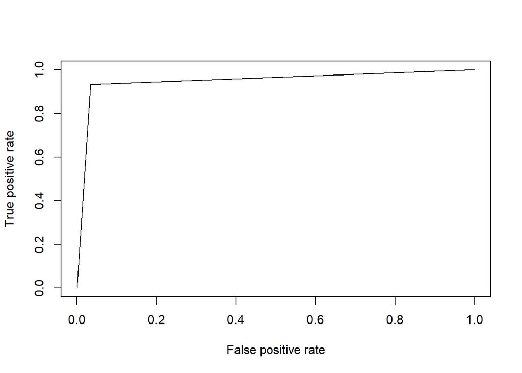

```r
plot(roc_knn)
```

## 5.4 Area under the ROC Curve

AUC provides an aggregate measure of performance across all possible classification thresholds. One way of interpreting AUC is as the probability that the model ranks a random positive example more highly than a random negative example.

```r
auc_knn <- performance(wholesaleknn_roc, measure = "auc")
auc_knn <- auc_knn@y.values[[1]]
print(auc_knn)
```

```
## [1] 0.9488603
```

AUC(area under receiver operating characteristic(ROC)curve) of 0.949 is a high score.

# 6 Predict using Caret (NN) Package

The coding syntax using the Nearest Neighbor algorithm in the Caret package is relatively simpler compared to the above Nearest Neighbor algorithm steps in R.

```r
library(caret)
trCtrl <- trainControl(method = "repeatedcv",
                          number = 5,
                          repeats =3)
set.seed(10)
knnfit <- train(Industry~.,
             data = wholesale.init,
             method = "knn",
             tuneLength = 21, # try 21 different values of k
             trControl = trCtrl,
             preProc = c("center", "scale"))
knnfit
```

```
## k-Nearest Neighbors
##
## 440 samples
##   6 predictor
##   2 classes: 'horeca', 'retail'
##
## Pre-processing: centered (6), scaled (6)
## Resampling: Cross-Validated (5 fold, repeated 3 times)
## Summary of sample sizes: 353, 351, 352, 351, 353, 353, ...
## Resampling results across tuning parameters:
##
##   k   Accuracy   Kappa
##    5  0.9114069  0.7988072
##    7  0.9113808  0.7991671
##    9  0.9106060  0.7975063
##   11  0.9106665  0.7977615
##   13  0.9069471  0.7888043
##   15  0.9046570  0.7836107
##   17  0.9107182  0.7964746
##   19  0.9107095  0.7955787
##   21  0.9137916  0.8022695
##   23  0.9152809  0.8058751
##   25  0.9152813  0.8055834
##   27  0.9137142  0.8007870
##   29  0.9130168  0.7998198
##   31  0.9130168  0.7993775
##   33  0.9122506  0.7970917
##   35  0.9137744  0.7998875
##   37  0.9077304  0.7856484
##   39  0.9054488  0.7799966
##   41  0.9054231  0.7800479
##   43  0.9054401  0.7793919
##   45  0.9039248  0.7751886
##
## Accuracy was used to select the optimal model using the largest value.
## The final value used for the model was k = 25.
```

Accuracy achieved 91.5% at k=25

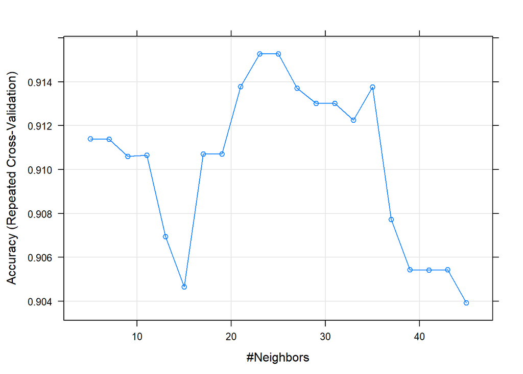

[output not shown]

```r
plot(knnfit)
```

## 6.1 Confusion Matrix

```r
knnPredict <- predict(knnfit, newdata = wholesale_test_c)
#Get the confusion matrix to see accuracy value and other parameter values
confusionMatrix(knnPredict, wholesale_test_c$Industry )
```

```
## Confusion Matrix and Statistics
##
##           Reference
## Prediction horeca retail
##     horeca     54      2
##     retail      5     27
##
##                Accuracy : 0.9205
##                  95% CI : (0.843, 0.9674)
##     No Information Rate : 0.6705
##     P-Value [Acc > NIR] : 2.78e-08
##
##                   Kappa : 0.8246
##
##  Mcnemar's Test P-Value : 0.4497
##
##             Sensitivity : 0.9153
##             Specificity : 0.9310
##          Pos Pred Value : 0.9643
##          Neg Pred Value : 0.8438
##              Prevalence : 0.6705
##          Detection Rate : 0.6136
##    Detection Prevalence : 0.6364
##       Balanced Accuracy : 0.9231
##
##        'Positive' Class : horeca
##
```

Using the Confusion Matrix, we could calculate the accuracy, precision, sensitivity and specificity of the classifier as follows:

```r
paste("Accuracy: ", round(((54+27)/nrow(wholesale_test_c)) * 100,2), "%", sep="")
```

```
## [1] "Accuracy: 92.05%"
```

```r
paste("Precision: ", round((54/(54+2)) * 100,2), "%", sep="")
```

```
## [1] "Precision: 96.43%"
```

```r
paste("Neg Pred : ", round((27/(27+5)) * 100,2), "%", sep="")
```

```
## [1] "Neg Pred : 84.38%"
```

```r
paste("Sensitivity (aka: Recall): ", round((54/(54+5)) * 100,2), "%", sep="")
```

```
## [1] "Sensitivity (aka: Recall): 91.53%"
```

```r
paste("Specificity: ", round((27/(27+2)) * 100,2), "%", sep="")
```

```
## [1] "Specificity: 93.1%"
```

```r
knnPredict1 <- predict(knnfit, newdata = wholesale_test_c)
knnPredict1 <- as.character(knnPredict1)
knnPredict1[knnPredict1=="horeca"] <- 1
knnPredict1[knnPredict1=="retail"] <- 0
knnPredict1 <- as.numeric(knnPredict1)
wholesale_test_c$Industry <- as.character(wholesale_test_c$Industry)
wholesale_test_c$Industry[wholesale_test_c$Industry =="horeca"] <- 1
wholesale_test_c$Industry[wholesale_test_c$Industry =="retail"] <- 0
Industry <- as.numeric(wholesale_test_c$Industry)
```

## 6.2 ROC Curve

```r
library(ROCR)
# ROCR::prediction(predictions, labels)
wholesaleknc_roc <- ROCR::prediction(knnPredict1,Industry)
# tpr/ sensitivity: true positive rate
# fpr: false positive rate
roc_knc <- performance(wholesaleknc_roc, "tpr", "fpr")
```

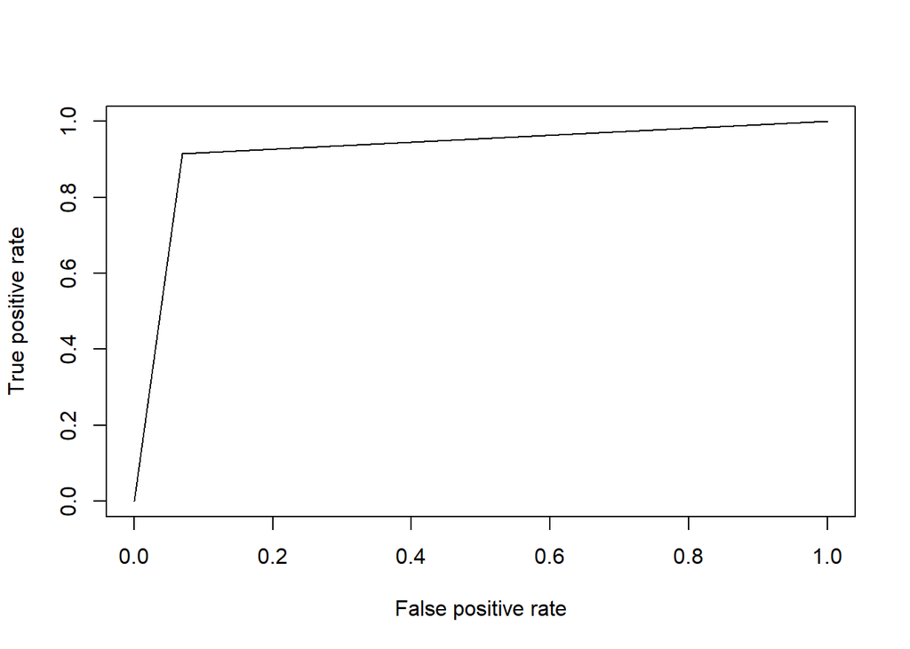

```r
plot(roc_knc)
```

## 6.3 Area under the ROC Curve

```r
auc_knc <- performance(wholesaleknc_roc, measure = "auc")
auc_knc <- auc_knc@y.values[[1]]
print(auc_knc)
```

```
## [1] 0.9231444
```

AUC(area under receiver operating characteristic(ROC) curve) of 0.923 is a high score.

# 7 Logistic Regression

## 7.1 Preprocessing

Based on Industry values of horeca and retail, we reassign the corresponding values in the Channel to 1 and 0 in the train and test data before performing the logistic regression.

```r
wholesale_train$Channel <- as.numeric(wholesale_train$Industry, levels = c("horeca", "retail"))
wholesale_test$Channel <- as.numeric(wholesale_test$Industry, levels = c("horeca", "retail"))
wholesale_train$Channel[wholesale_train$Channel == 1] <- 0
wholesale_train$Channel[wholesale_train$Channel == 2] <- 1
wholesale_test$Channel[wholesale_test$Channel == 1] <- 0
wholesale_test$Channel[wholesale_test$Channel == 2] <- 1
wholesale_train$Channel <- as.integer(wholesale_train$Channel)
wholesale_test$Channel <- as.integer(wholesale_test$Channel)
```

```r
wholesale.glm.all <- glm(Channel ~ Fresh + Milk + Frozen + Detergents_Paper + Delicassen, family = "binomial", data = wholesale_train)
```

[output not shown]

Like R-squared, AIC is a statistical meaure of how close the data are to the fitted regression line. It gives us a measure of fit: the model with the lowest AIC value will help us minimize residual error in the model. The AIC with all variables used is 185.01.

Residual deviance shows how well the model predicts when the predictors are included.

Residual deviance: 173.01 on 346 degrees of freedom

## 7.3 Stepwise Regression with Backward Selection

Stepwise Regression is an algorithm that iteratively add and remove independent variable in the regression equation. Here, with backward selection, it starts with all predictors and stops when the remaining predictors in the model is statistically significant.

```r
step(wholesale.glm.all, direction = "backward")
```

```
## Start:  AIC=185.01
## Channel ~ Fresh + Milk + Frozen + Detergents_Paper + Delicassen
```

```
##                    Df Deviance    AIC
## - Fresh             1   173.02 183.02
## - Delicassen        1   173.09 183.09
## <none>                  173.01 185.01
## - Frozen            1   175.83 185.83
## - Milk              1   177.46 187.46
## - Detergents_Paper  1   282.53 292.53
```

```
##
## Step:  AIC=183.02
## Channel ~ Milk + Frozen + Detergents_Paper + Delicassen
```

```
##                    Df Deviance    AIC
## - Delicassen        1   173.09 181.09
## <none>                  173.02 183.02
## - Frozen            1   175.90 183.90
## - Milk              1   177.55 185.55
## - Detergents_Paper  1   286.32 294.32
```

```
##
## Step:  AIC=181.09
## Channel ~ Milk + Frozen + Detergents_Paper
```

```
##                    Df Deviance    AIC
## <none>                  173.09 181.09
## - Frozen            1   176.38 182.38
## - Milk              1   177.60 183.60
## - Detergents_Paper  1   286.33 292.33
```

```
##
## Call:  glm(formula = Channel ~ Milk + Frozen + Detergents_Paper, family = "binomial",
##     data = wholesale_train)
##
## Coefficients:
##      (Intercept)              Milk            Frozen  Detergents_Paper
##           -3.342             8.200            -9.024            40.408
##
## Degrees of Freedom: 351 Total (i.e. Null);  348 Residual
## Null Deviance:       441.9
## Residual Deviance: 173.1     AIC: 181.1
```

## 7.4 Fitted Model

Looking at the model with the lowest AIC(in this case, 181.1), the predictors used in this model are Milk + Frozen + Detergents_Paper.

```r
wholesale.glm.adj <- glm(Channel ~ Detergents_Paper+Milk, family = "binomial", data = wholesale_test)
```

Variance Inflation Factor(vif) quantifies the severity of multicollinearity in a multiple regression analysis.A VIF of 1 means that there is no correlation among the jth predictor and the remaining predictor variables. A VIF between 5 and 10 indicates high correlation that may be problematic.

```r
library(car)
#vif(wholesale.glm.adj)
```

```r
summary(wholesale.glm.adj)
```

```
##
## Call:
## glm(formula = Channel ~ Detergents_Paper + Milk, family = "binomial",
##     data = wholesale_test)
##
## Deviance Residuals:
##      Min        1Q    Median        3Q       Max
## -2.40759  -0.27100  -0.18332   0.01647   2.03238
##
## Coefficients:
##                  Estimate Std. Error z value Pr(>|z|)
## (Intercept)        -4.467      1.009  -4.429 9.48e-06 ***
## Detergents_Paper   47.036     10.734   4.382 1.18e-05 ***
## Milk                4.097      4.620   0.887    0.375
## ---
## Signif. codes:  0 '***' 0.001 '**' 0.01 '*' 0.05 '.' 0.1 ' ' 1
##
## (Dispersion parameter for binomial family taken to be 1)
##
##     Null deviance: 111.559  on 87  degrees of freedom
## Residual deviance:  36.675  on 85  degrees of freedom
## AIC: 42.675
##
## Number of Fisher Scoring iterations: 7
```

```r
#wholesale.glm.one <- glm(Channel ~ Detergents_Paper, family = "binomial", data = wholesale_test)
#summary(wholesale.glm.one)
```

## 7.5 Confusion Matrix

Use the fitted model to do predictions of the test data

```r
wholesale_test$pred.Risk <- predict(wholesale.glm.adj, wholesale_test, type = "response")
```

We set a “risk” threshold of 0.5 and predict any prediction that exceed the threshold as a default of 1.

```r
contab <- table("predicted"=as.numeric(wholesale_test$pred.Risk>=0.5), "actual"=wholesale_test$Channel)
wholesale_test$predicted<- ifelse (wholesale_test$pred.Risk>=0.5, 1, 0)
wholesale_test_2 <-data.frame(cbind(wholesale_test$predicted, wholesale_test$Channel, wholesale_test[, 1:6]))
```

```r
print(accuracy(wholesale_test_2))
```

```
## [1] 89.77273
```

```r
confusionMatrix(contab,positive ="1")
```

```
## Confusion Matrix and Statistics
##
##          actual
## predicted  0  1
##         0 55  5
##         1  4 24
##
##                Accuracy : 0.8977
##                  95% CI : (0.8147, 0.9522)
##     No Information Rate : 0.6705
##     P-Value [Acc > NIR] : 6.456e-07
##
##                   Kappa : 0.7665
##
##  Mcnemar's Test P-Value : 1
##
##             Sensitivity : 0.8276
##             Specificity : 0.9322
##          Pos Pred Value : 0.8571
##          Neg Pred Value : 0.9167
##              Prevalence : 0.3295
##          Detection Rate : 0.2727
##    Detection Prevalence : 0.3182
##       Balanced Accuracy : 0.8799
##
##        'Positive' Class : 1
##
```

```r
paste("Accuracy: ", round(((55+26)/nrow(wholesale_test)) * 100,2), "%", sep="")
```

```
## [1] "Accuracy: 92.05%"
```

```r
paste("Precision : ", round((26/(26+4)) * 100,2), "%", sep="")
```

```
## [1] "Precision : 86.67%"
```

```r
paste("Neg Pred: ", round((55/(55+3)) * 100,2), "%", sep="")
```

```
## [1] "Neg Pred: 94.83%"
```

```r
paste("Sensitivity (aka Recall): ", round((26/(26+3)) * 100,2), "%", sep="")
```

```
## [1] "Sensitivity (aka Recall): 89.66%"
```

```r
paste("Specificity: ", round((55/(55+4)) * 100,2), "%", sep="")
```

```
## [1] "Specificity: 93.22%"
```

## 7.6 ROC Curve

```r
library(ROCR)
# ROCR::prediction(predictions, labels)
wholesalelog_roc <- ROCR::prediction(wholesale_test$predicted, wholesale_test$Channel)
# tpr/ sensitivity: true positive rate
# fpr: false positive rate
roc_log <- performance(wholesalelog_roc, "tpr", "fpr")
```

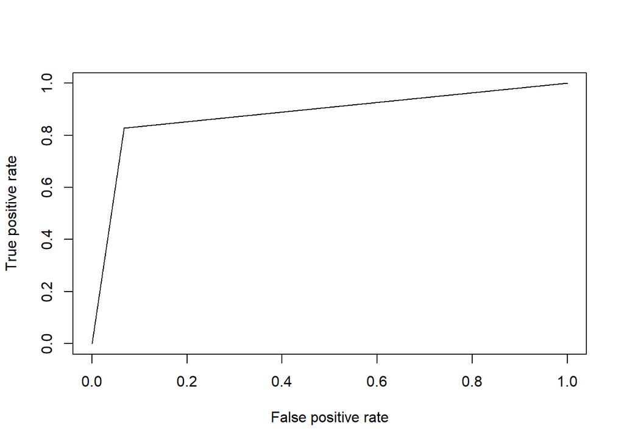

```r
plot(roc_log)
```

## 7.7 Area under the ROC Curve

```r
auc_log <- performance(wholesalelog_roc, measure = "auc")
auc_log <- auc_log@y.values[[1]]
print(auc_log)
```

```
## [1] 0.8798948
```

# 8 Summary

Below please find the side by side comparison of the approaches

```r
options(knitr.table.format = "html")
library(kableExtra)
dd %>%
  kable() %>%
  kable_styling()
```

| x |
| --- |
| Desc |
| Accuracy |
| Precision |
| Neg Pred |
| Sensitivity |
| Specificity |
| AUC |

[output not shown]

| x |
| --- |
| NN_Caret |
| 92.05% |
| 96.43% |
| 84.38% |
| 91.53% |
| 93.1% |
| 0.923 |

[output not shown]

[output not shown]

[output not shown]

[output not shown]

To achieve higher precision for horeca customers, the Nearest Neighbor algorithm would be preferred.

For this assignment, we achieve a better accuracy result when using min-max score normalization compared to z-score standardization.